# ML Model Overview & Performance Report: Defect Risk Scorer

Section 1

## Executive Summary

This report summarises the pre-production defect risk scorer, a machine learning model that estimates, for every production work order before it runs, how likely the job is to produce a defect. It was trained on three years (January 2023 to December 2025) of shop-floor history drawn from the plant's machine, ERP, and quality data systems. Its output is embedded inside the ERP work-order queue so planners see a risk tier and the reasons behind it before releasing a job.

In January 2026, the scorer evaluated **270** work orders. It flagged **33** as High risk, and **32 of those 33** genuinely produced defects, a High-tier precision of **97.0%** with just 1 false alarm. Widening to the Medium threshold, the flagged set of 58 jobs caught **50 of the period's defective jobs** at **86.2%** precision. For reference, the model's held-out validation ROC-AUC is **0.74** against 0.50 for a coin-flip, so it ranks risky jobs well above chance.

That accuracy converts directly into avoided scrap. In January 2026, the 50 defective jobs the model correctly flagged carried about **$8,516** in scrap and rework cost. Catching those defects before the jobs ran would avoid on the order of **$102,000 a year**, a meaningful share of the roughly $162,000 the shop currently loses annually to defects on jobs like these. Because nearly every High-risk flag is a real defect, a planner who pulls just those 33 jobs for a second look before release is almost never wasting time.

270

Jobs Scored

January 2026

33

High Risk Flags

12.2% of jobs · 97.0% precision

58

Medium Risk Flags

21.5% of jobs · 86.2% precision

Alongside the score and tier, every flag lists the specific conditions that drove it. The signals most often behind a flag are below.

[output not shown]

Section 2

## Model Overview

Section 2.1

## What This Model Does

The model answers one question for every work order, each time a job is about to be released: **how likely is this job to produce a defect?** It does not stop the job or decide anything on its own; it is an early-warning and prioritisation tool that surfaces the riskiest jobs for a human to review before production starts.

Each score is a defect probability sorted into a plain risk tier: jobs at or above 0.75 are **High** (treat as the shift's priority review), 0.65 to 0.75 is **Medium** (worth a look when capacity allows), and below that is **Low** (no action).

The score is delivered where the work is planned. The screenshot below shows the scorer embedded in the ERP work-order queue: every job carries a colour-coded defect-risk tier, and a summary panel totals the High, Medium, and Low counts, so planners can spot and hold the riskiest jobs without leaving the system they already use.

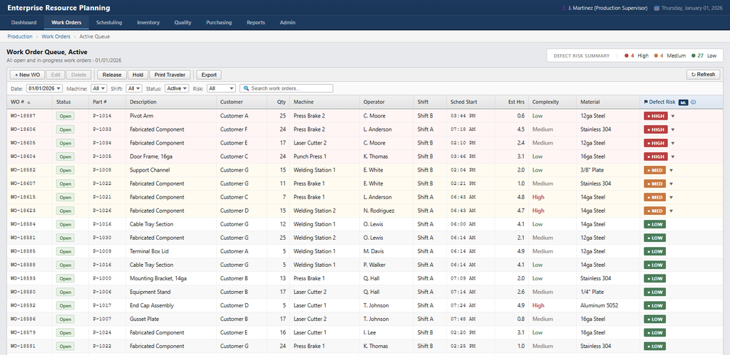

Section 2.2

## Training Data Overview

The model learned from three years of production work orders (January 2023 to December 2025), one row per job. Each row is an integrated record stitched together from three source systems: machine and shift context from the MES, job, supplier, operator, and schedule data from the ERP, and the inspection outcome from the QMS. That join is what lets the model see cross-system combinations, such as an older machine running a high-complexity job on a thin-gauge lot, that no single system reveals on its own.

The chart below shows the full training window: about 240 work orders a month across the three years, split by time into the train, validation, and test sets, with the monthly defect rate from the QMS inspection records overlaid. The defect rate holds near 49.9% throughout, so the model sees a balanced and stable signal across the whole window rather than a moving target.

Work Orders and Defect Rate by Month, 2023 to 2025

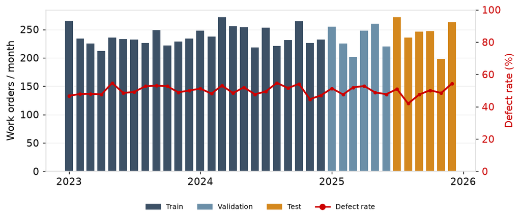

The integrated data also shows where defects concentrate. Broken out by machine type, historical defect rates range from about 45.9% to 55.2%, and similar gaps appear across shifts, suppliers, and part complexity. Those cross-system differences are the signal the model turns into a per-job risk score; the full feature set and how each feature is built are documented in the technical report.

Historical Defect Rate by Machine Type

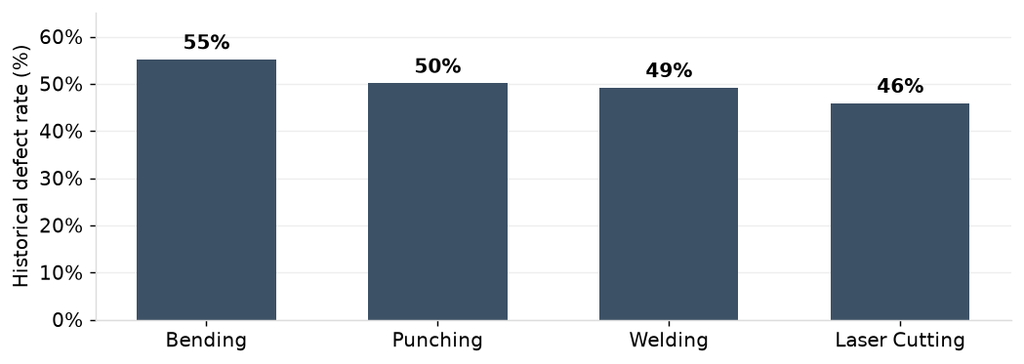

Section 3

## Model Performance

Section 3.1

## Scoring Summary

Work Orders by Risk Tier

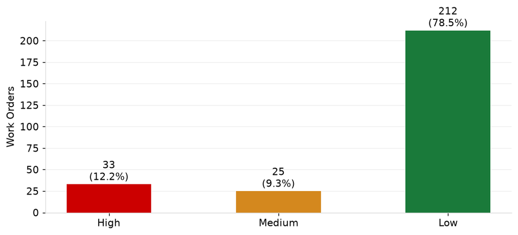

The score itself is a defect probability; the dashed lines mark the High and Medium tier thresholds, and jobs to the right of each line are flagged at that tier.

Distribution of Predicted Defect Probabilities

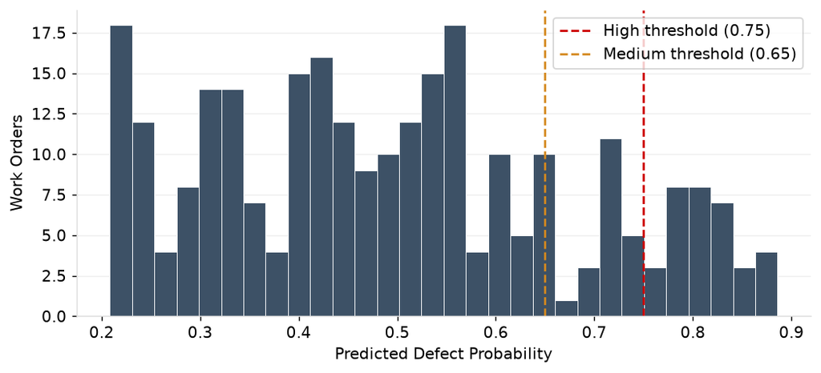

Weekly Risk-Tier Distribution

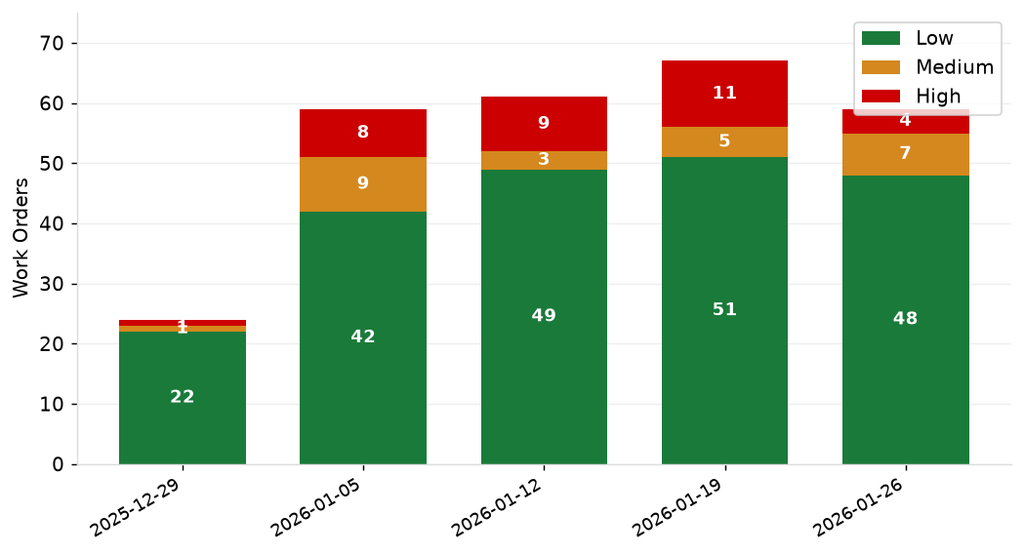

Section 3.2

## Accuracy and Validation

Because this period covers historical jobs with known outcomes, the flags can be checked against what actually happened. Precision is the share of flags that were correct; recall is the share of all defective jobs the model caught. High precision with lower recall is deliberate: the model is tuned to flag only jobs it is confident about, so the review list stays trustworthy.

97.0%

High-tier precision

32 of 33 flags correct

86.2%

Medium-tier precision

50 of 58 flags correct

0.74

Validation ROC-AUC

vs 0.50 for chance

37.0%

Defect catch rate

share of defects flagged

| Risk Tier | Threshold | Jobs Flagged | True Positives | False Positives | Precision | Recall |
| --- | --- | --- | --- | --- | --- | --- |
| High | 0.75 | 33 (12.2%) | 32 | 1 | 97.0% | 23.7% |
| Medium | 0.65 | 58 (21.5%) | 50 | 8 | 86.2% | 37.0% |

Measured against a no-model baseline, the lift is large. With a 50.0% defect base rate, flagging jobs at random would be right about half the time, whereas the model's High-tier flags are correct **97.0%** of the time, close to double the base rate, and its held-out validation ROC-AUC of **0.74** sits well above the 0.50 of a coin-flip. The tradeoff is recall: the model deliberately flags only the jobs it is most confident about, so it surfaces a focused, high-value subset of defects rather than trying to catch them all.

Section 3.3

## Sample Model Output

Presented below is what the model produces for the period's highest-risk jobs: the score, the tier, and the plain-language reasons behind the flag, exactly as a planner sees them in the ERP queue.

WO-18773 High 88.6% probability ✗ Outcome: Defective

**Historical operator performance associated with elevated defect risk** increases the risk score; **Part complexity increases setup sensitivity** increases the risk score; **Extended production run with above-average historical variation** increases the risk score.

WO-18682 High 88.2% probability ✗ Outcome: Defective

**Historical operator performance associated with elevated defect risk** increases the risk score; **Extended production run with above-average historical variation** increases the risk score; **Press brake job with above-average defect history for this shift configuration** increases the risk score.

WO-18788 High 88.2% probability ✗ Outcome: Defective

**Historical operator performance associated with elevated defect risk** increases the risk score; **Extended production run with above-average historical variation** increases the risk score; **Press brake job with above-average defect history for this shift configuration** increases the risk score.

WO-18691 High 87.1% probability ✗ Outcome: Defective

**Historical operator performance associated with elevated defect risk** increases the risk score; **Extended production run with above-average historical variation** increases the risk score; **Thin gauge material lot with above-average historical defect rate** increases the risk score.

WO-18587 High 84.8% probability ✗ Outcome: Defective

**Historical operator performance associated with elevated defect risk** increases the risk score; **Extended production run with above-average historical variation** increases the risk score; **Press brake job with above-average defect history for this shift configuration** increases the risk score.

Section 3.4

## What It Can and Cannot Predict

- **It predicts occurrence, not severity or cost.** A High flag means a defect is likely, not how many parts will fail or what the scrap will cost; flagged jobs range from a single bad part to a full-batch scrap event.
- **It is conservative by design.** High precision comes at the cost of recall: the model flags only jobs it is confident about and will miss defective jobs that do not match the patterns it has learned.
- **Some inputs can be missing at release.** Supplier and lot-certification signals depend on material being scanned; for jobs released before that scan (historically about 15%), those drivers are unavailable.
- **It is decision support, not automation.** The model ranks and explains; a person decides which flagged jobs to review or hold.
- **It stays current through monitoring.** Performance is tracked every period and the model is retrained if precision slips or the defect rate drifts, as detailed in the monitoring report.